# 01_EDA

```python
from IPython.display import display, HTML

display(HTML("""
<div style="background: linear-gradient(135deg, #8B0000 0%, #C0392B 40%, #E74C3C 70%, #F39C12 100%); padding: 50px 40px; border-radius: 12px; text-align: center; font-family: Georgia, serif; box-shadow: 0 4px 20px rgba(0,0,0,0.3);">

  <span style="color: #FFD700; font-weight: bold; font-size: 14px; letter-spacing: 2px;">CUC - COLEGIO UNIVERSITARIO DE CARTAGO</span>

  <hr style="border: 1px solid rgba(255,215,0,0.5); margin: 15px 0;">

  <h1 style="color: #FFD700; font-size: 42px; margin: 20px 0 10px 0; text-shadow: 2px 2px 4px rgba(0,0,0,0.5); letter-spacing: 3px;">
    Movie Insights
  </h1>

  <h2 style="color: white; font-size: 22px; font-weight: normal; margin: 5px 0 25px 0; letter-spacing: 1px;">
    Analisis Exploratorio de Datos (EDA)
  </h2>

  <hr style="border: 1px solid rgba(255,215,0,0.5); margin: 15px 0;">

  <p style="color: #FFD700; font-weight: bold; font-size: 15px; margin: 8px 0;">Curso: <span style="color: white; font-weight: normal;">BD-143 Programacion II</span></p>
  <p style="color: #FFD700; font-weight: bold; font-size: 15px; margin: 8px 0;">Profesor: <span style="color: white; font-weight: normal;">Osvaldo Gonzalez Chaves</span></p>
  <p style="color: #FFD700; font-weight: bold; font-size: 15px; margin: 8px 0;">Proyecto: <span style="color: white; font-weight: normal;">Proyecto II</span></p>
  <p style="color: #FFD700; font-weight: bold; font-size: 15px; margin: 8px 0;">Cuatrimestre: <span style="color: white; font-weight: normal;">I Cuatrimestre 2026</span></p>

  <hr style="border: 1px solid rgba(255,215,0,0.5); margin: 20px 0 15px 0;">

  <p style="color: #FFD700; font-size: 13px; letter-spacing: 2px; margin-bottom: 10px;">ELABORADO POR</p>
  <p style="color: white; font-size: 20px; font-weight: bold; margin: 5px 0;">Luis Diego Montero</p>
  <p style="color: white; font-size: 20px; font-weight: bold; margin: 5px 0;">Nadin Rojas</p>

</div>
"""))

from IPython.display import display, HTML

display(HTML("""
<style>

/* Titulos H1 */
.jp-RenderedMarkdown h1 {
  background: linear-gradient(135deg, #8B0000, #C0392B, #F39C12);
  -webkit-background-clip: text;
  -webkit-text-fill-color: transparent;
  background-clip: text;
  font-family: Georgia, serif !important;
  font-size: 2em !important;
  border-bottom: 3px solid #C0392B !important;
  padding-bottom: 8px !important;
}

/* Titulos H2 */
.jp-RenderedMarkdown h2 {
  color: #E74C3C !important;
  font-family: Georgia, serif !important;
  border-left: 5px solid #F39C12 !important;
  padding-left: 12px !important;
}

/* Titulos H3 */
.jp-RenderedMarkdown h3 {
  color: #F39C12 !important;
  border-bottom: 1px solid rgba(243,156,18,0.4) !important;
  padding-bottom: 4px !important;
}

</div>
"""))
```

CUC - COLEGIO UNIVERSITARIO DE CARTAGO

Movie Insights

Analisis Exploratorio de Datos (EDA)

Curso: BD-143 Programacion II

Profesor: Osvaldo Gonzalez Chaves

Proyecto: Proyecto II

Cuatrimestre: I Cuatrimestre 2026

ELABORADO POR

Luis Diego Montero

Nadin Rojas

[output not shown]

## 2. Resumen Descriptivo

El resumen descriptivo nos da informacion estadística de las variables numéricas del dataset. Calculamos las siguientes medidas para cada variable:

| Medida | Descripción |
| --- | --- |
| `count` | Número de valores no nulos |
| `mean` | Promedio aritmético |
| `std` | Desviación estándar (qué tan dispersos están los datos) |
| `min` / `max` | Valor mínimo y máximo |
| `Q1` / `Q3` | Percentil 25 y 75 (rango intercuartílico) |
| `median` | Valor central de la distribución |

En este dataset las variables numéricas son `vote_average` (calificación promedio de 0 a 10) y `vote_count` (cantidad de votos recibidos).

```python
numericas = df.select_dtypes(include='number')

resumen = numericas.agg([
    'count', 'mean', 'std', 'min',
    lambda x: x.quantile(0.25),
    'median',
    lambda x: x.quantile(0.75),
    'max'
]).round(2)

resumen.index = ['count', 'mean', 'std', 'min', 'Q1', 'median', 'Q3', 'max']
resumen
```

|  | vote_average | vote_count |
| --- | --- | --- |
| count | 9999.00 | 9999.00 |
| mean | 4.55 | 221.90 |
| std | 2.97 | 879.47 |
| min | 0.00 | 0.00 |
| Q1 | 0.00 | 0.00 |
| median | 5.71 | 6.00 |
| Q3 | 6.72 | 61.00 |
| max | 10.00 | 21265.00 |

## 3. Interpretación de resultados en cuanto al resumen descriptivo

### vote_average (Calificación promedio)

- La calificación **promedio es 4.55**, pero la **mediana es 5.71**, lo que indica que la distribución está dividida hacia la izquierda: hay muchas películas con calificación 0 que jalan el promedio hacia abajo.
- El **Q1 es 0.0**, lo que significa que al menos el 25% de las películas no tienen ninguna calificación registrada todavía.
- El rango va de **0 a 10**, cubriendo toda la escala posible.
- La desviación estándar de **2.97** indica alta variabilidad entre películas.

### vote_count (Número de votos)

- El **promedio es 221 votos**, pero la **mediana es solo 6**, lo que revela una distribución extremadamente asimétrica: unas pocas películas concentran la mayoría de los votos.
- El **75% de las películas tiene 61 votos o menos** (Q3 = 61), mientras que el máximo llega a **21,265 votos**, lo que confirma la presencia de outliers significativos.
- El **Q1 de 0** indica que muchas películas no tienen votos aún, probablemente estrenos recientes o producciones de nicho.

### Conclusión general

Estos resultados sugieren que el dataset contiene una mezcla de películas muy populares con muchos votos y películas poco conocidas o muy recientes con poca interacción. Para análisis posteriores será importante considerar filtrar películas con `vote_count` muy bajo, ya que una calificación basada en pocos votos no es estadísticamente representativa.

## 4. Matriz de Correlación

La matriz de correlación mide qué tan relacionadas están dos variables numéricas entre sí. El coeficiente va de **-1 a 1**:

| Valor | Interpretación |
| --- | --- |
| Cercano a 1 | Correlación positiva fuerte |
| Cercano a -1 | Correlación negativa fuerte |
| Cercano a 0 | Sin correlación |

Analizamos si existe relación entre la **calificación promedio** (`vote_average`) y la **cantidad de votos** (`vote_count`).

```
              vote_average  vote_count
vote_average       1.00000     0.20346
vote_count         0.20346     1.00000
```

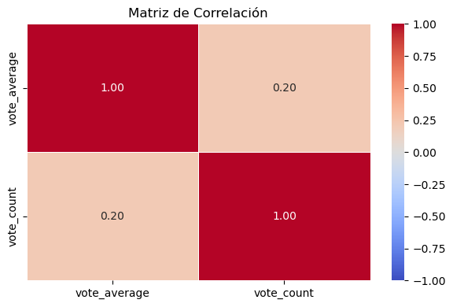

```python
import seaborn as sns
import matplotlib.pyplot as plt

correlacion = df[['vote_average', 'vote_count']].corr()

print(correlacion)

plt.figure(figsize=(6, 4))
sns.heatmap(correlacion, annot=True, cmap='coolwarm', fmt='.2f',
            linewidths=0.5, vmin=-1, vmax=1)
plt.title('Matriz de Correlación')
plt.tight_layout()
plt.show()
```

### Interpretación

La correlación entre `vote_average` y `vote_count` es **0.20**, lo que indica una correlación positiva muy débil. Esto significa que existe una ligera tendencia a que las películas con más votos tengan calificaciones más altas, pero la relación es tan débil que prácticamente no hay conexión entre ambas variables.

Es decir que una película tenga muchos votos **no garantiza** que sea bien calificada, ni que una película bien calificada vaya a recibir muchos votos. Son variables casi independientes entre sí.

Por otro lado la diagonal muestra **1.00** porque cualquier variable tiene correlación perfecta consigo misma.

## 5. Análisis de Outliers

Un outlier es un valor atípico que se aleja significativamente del resto. Usamos el método **IQR (Rango Intercuartílico)** ya que se considera outlier cualquier valor por debajo de `Q1 - 1.5*IQR` o por encima de `Q3 + 1.5*IQR`.

Detectar outliers es importante porque pueden distorsionar promedios y modelos posteriores.

```python
def detectar_outliers(df, columna):
    Q1 = df[columna].quantile(0.25)
    Q3 = df[columna].quantile(0.75)
    IQR = Q3 - Q1
    limite_inf = Q1 - 1.5 * IQR
    limite_sup = Q3 + 1.5 * IQR
    outliers = df[(df[columna] < limite_inf) | (df[columna] > limite_sup)]
    print(f"--- {columna} ---")
    print(f"  Límite inferior: {limite_inf:.2f}")
    print(f"  Límite superior: {limite_sup:.2f}")
    print(f"  Outliers encontrados: {len(outliers)} ({len(outliers)/len(df)*100:.1f}%)")
    return outliers

outliers_avg   = detectar_outliers(df, 'vote_average')
outliers_count = detectar_outliers(df, 'vote_count')
```

```
--- vote_average ---
  Límite inferior: -10.09
  Límite superior: 16.81
  Outliers encontrados: 0 (0.0%)
--- vote_count ---
  Límite inferior: -91.50
  Límite superior: 152.50
  Outliers encontrados: 1721 (17.2%)
```

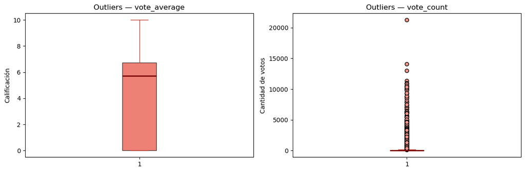

```python
fig, axes = plt.subplots(1, 2, figsize=(12, 4))

axes[0].boxplot(df['vote_average'].dropna(), patch_artist=True,
                boxprops=dict(facecolor='#e74c3c', alpha=0.7),
                medianprops=dict(color='#7b0000', linewidth=2),
                whiskerprops=dict(color='#c0392b'),
                capprops=dict(color='#c0392b'),
                flierprops=dict(markerfacecolor='#e74c3c', marker='o'))
axes[0].set_title('Outliers — vote_average')
axes[0].set_ylabel('Calificación')

axes[1].boxplot(df['vote_count'].dropna(), patch_artist=True,
                boxprops=dict(facecolor='#f1948a', alpha=0.7),
                medianprops=dict(color='#7b0000', linewidth=2),
                whiskerprops=dict(color='#c0392b'),
                capprops=dict(color='#c0392b'),
                flierprops=dict(markerfacecolor='#f1948a', marker='o'))
axes[1].set_title('Outliers — vote_count')
axes[1].set_ylabel('Cantidad de votos')

plt.tight_layout()
plt.show()
```

### Filtrado de outliers para análisis de calidad

Como se observó, muchas películas tienen `vote_average = 0` y `vote_count = 0`, lo que no indica que sean malas, sino que simplemente **aún no tienen votos**. Incluirlas en análisis de calidad distorsionaría los resultados.

Por eso creamos un DataFrame filtrado que excluye estas películas, conservando solo las que tienen al menos 10 votos.

```python
# Filtramos películas sin votos
df_calidad = df[df['vote_count'] >= 10].copy()

print(f"Dataset original:  {len(df)} películas")
print(f"Dataset filtrado:  {len(df_calidad)} películas")
print(f"Películas removidas: {len(df) - len(df_calidad)} ({(len(df) - len(df_calidad))/len(df)*100:.1f}%)")
print()
print("Resumen vote_average después del filtro:")
print(df_calidad['vote_average'].describe().round(2))
```

```
Dataset original:  9999 películas
Dataset filtrado:  4499 películas
Películas removidas: 5500 (55.0%)

Resumen vote_average después del filtro:
count    4499.00
mean        6.30
std         0.94
min         1.80
25%         5.74
50%         6.38
75%         6.94
max         9.10
Name: vote_average, dtype: float64
```

### Interpretación del filtrado

Al aplicar el filtro de `vote_count >= 10`, el dataset se redujo de **9,999 a 4,499 películas**, eliminando el **55%** de los registros. Esto confirma que más de la mitad del dataset corresponde a estrenos recientes o producciones sin actividad de votación significativa.

El impacto en la calificación promedio es notable:

| Medida | Sin filtro | Con filtro |
| --- | --- | --- |
| Media | 4.55 | 6.30 |
| Desviación estándar | 2.97 | 0.94 |
| Mínimo | 0.00 | 1.80 |
| Mediana | 5.71 | 6.38 |

La media **subió casi 2 puntos** y la desviación estándar bajó de 2.97 a 0.94, lo que indica que los datos filtrados son mucho más consistentes y representativos de la opinión real del público.

## 6. Análisis por Año de Lanzamiento

Extraemos el año de `release_date` para analizar cómo ha evolucionado las películas y sus calificaciones entre 2020 y 2025.

```
      total_peliculas  calificacion_promedio  votos_promedio
anio
2020             1567                   4.49          245.06
2021             1874                   4.49          280.70
2022             1895                   4.81          250.98
2023             1626                   4.59          241.78
2024             1601                   4.50          189.74
2025             1436                   4.37           94.86
```

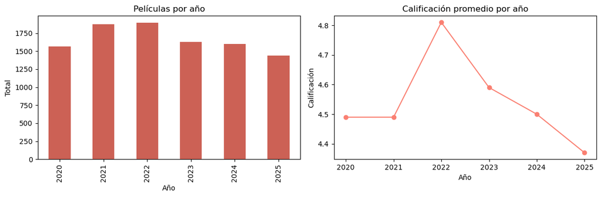

```python
df['release_date'] = pd.to_datetime(df['release_date'], errors='coerce')
df['anio'] = df['release_date'].dt.year

peliculas_por_anio = df.groupby('anio').agg(
    total_peliculas=('title', 'count'),
    calificacion_promedio=('vote_average', 'mean'),
    votos_promedio=('vote_count', 'mean')
).round(2)

print(peliculas_por_anio)

fig, axes = plt.subplots(1, 2, figsize=(12, 4))

peliculas_por_anio['total_peliculas'].plot(kind='bar', ax=axes[0],
                                            color='#c0392b', alpha=0.8)
axes[0].set_title('Películas por año')
axes[0].set_xlabel('Año')
axes[0].set_ylabel('Total')

peliculas_por_anio['calificacion_promedio'].plot(kind='line', ax=axes[1],
                                                  marker='o', color='salmon')
axes[1].set_title('Calificación promedio por año')
axes[1].set_xlabel('Año')
axes[1].set_ylabel('Calificación')

plt.tight_layout()
plt.show()
```

### Interpretación

Este análisis permite ver si la cantidad de películas producidas creció o disminuyó en el período, y si las calificaciones han mejorado o empeorado con el tiempo. Un dato que llama la atencion es que en en 2022 fue el año con mas peliculas producidas y con mejor calificacion promedio, por otro lado tenemos que en los años que las personas mas votaron fue del 2020 al 2022 una hipotesis de esto es que en esos años nos encontrabamos en pandemia y las personas estaban en sus casas lo que pudo llegar a ayudar e incrementar la interaccion de las personas con las peliculas.